# homework_4

Peter

2026-02-03

Sec 4.6 Exercises # 3, 5, 6, 9, 12, 15, 18, 23, 29

### Problem 3

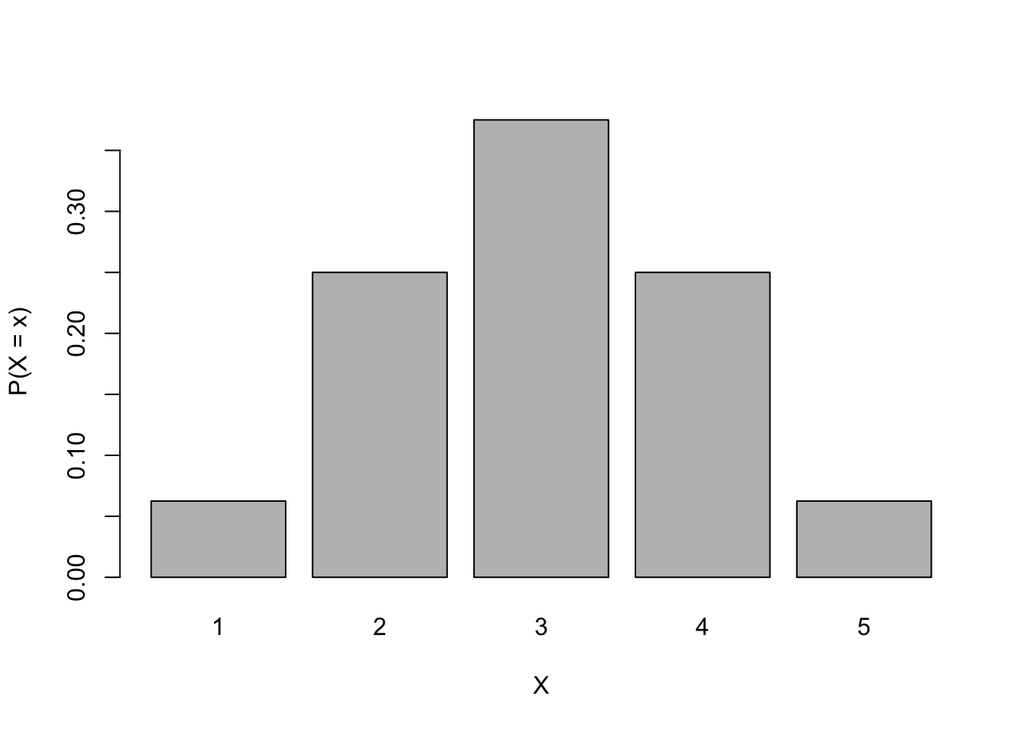

```r
x <- 1:5
px <- c(2/32, 8/32, 12/32, 8/32, 2/32)
barplot(px, names.arg = x, xlab = "X", ylab = "P(X = x)")
```

3. The most likely number of runs is the mode, which is $X=3$.

$P(X \leq 2) = P(X=1) + P(X=2) = \frac{10}{32}$.

### Problem 5

$P(X \geq 2) = 1 - P(X=1) = 1 - \frac{1}{6}=\frac{5}{6}$

$\mu = \sum x \cdot P(X=x) = \frac{13}{4} = 3.25$

$E[X^2] = \frac{14}{6} + \frac{41}{4} = \frac{151}{12}$

$\sigma^2 = \frac{151}{12} - 3.25^2 = 2.020833$

$\sigma = 1.42156$

### Problem 6

```r
x <- 4:24
px <- c(.001,.003,.008,.016,.027,.044,.062,.080,.097,.108,.113,.108,.096,.080,.062,.043,.027,.015,.008,.003,.001)

y <- seq(4, 24, by = 2)
py <- c(.028,.056,.083,.111,.139,.167,.139,.111,.083,.056,.028)

mu_x <- sum(x * px)
sd_x <- sqrt(sum(x^2 * px) - mu_x^2)

mu_y <- sum(y * py)
sd_y <- sqrt(sum(y^2 * py) - mu_y^2)

cat("X: mean =", mu_x, ", sd =", sd_x, "\n")
```

```
## X: mean = 14.014 , sd = 3.371617
```

```r
cat("Y: mean =", mu_y, ", sd =", sd_y, "\n")
```

```
## Y: mean = 14.014 , sd = 4.817863
```

$\mu_X = 14.014$ $\sigma_X = 3.371617$

$\mu_Y = 14.014$ $\sigma_Y = 4.817863$

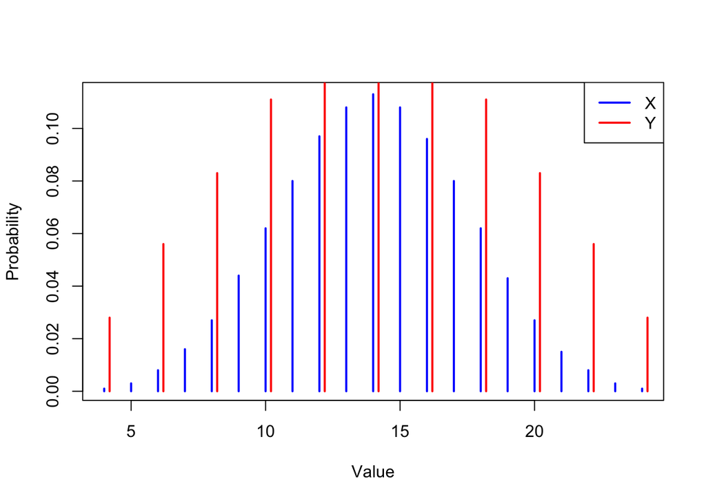

```r
plot(x, px, type = "h", lwd = 2, col = "blue", xlab = "Value", ylab = "Probability")
points(y + 0.2, py, type = "h", lwd = 2, col = "red")
legend("topright", legend = c("X", "Y"), col = c("blue", "red"), lwd = 2)
```

They are symmetric, having the same mean, though Y has a larger standard deviation since it only takes even values.  
The means match, but doubling increases variability too much and makes odd totals impossible. Four independent dice cancel out extremes better, giving a tighter distribution.

### Problem 9

$P(|Y| \geq 2) = P(Y = -4) + P(Y = -2) + P(Y = 2) + P(Y = 4) = \frac{10}{16}$

Y=-4: (0.5)(0.3)(0.3)(0.3) = 0.0135 Y=-2: (0.0315)+(0.0315)+(0.0525)+(0.0525) = 0.168 Y=0: (0.0735)+(0.1225)+(0.1225)+(0.1225)+(0.1225)+(0.0735)= 0.637 Y=2: (0.0315)+(0.0315)+(0.0525)+(0.0525) = 0.168 Y=4: (0.5)(0.3)(0.3)(0.3) = 0.0135

$\mu_a = 0$ $\sigma_a = \sqrt{16(\frac{1}{16}) + 4(\frac{4}{16}) + 4(\frac{4}{16}) + 16(\frac{1}{16})} = 2$

$\mu_c = 0$ $\sigma_c = \sqrt{16(0.0135) + 4(0.168) + 4(0.168) + 16(0.0135)} = 1.333$

Both distributions have the same mean of 0, but the gravitational pull reduces the standard deviation from 2 to 1.33, so the walker stays much closer to home on average.

### Problem 12

$E[S] = k \cdot \mu = 35$ $SD[S] = \sqrt{k} \cdot \sigma = \sqrt{10} \cdot 1.71 = 5.407495$

For a single spin X: $\mu = (1 \cdot 0.5) + (2 \cdot 0.25) + (3 \cdot 0.25) = 1.75$ $\sigma = \sqrt{(1^2 \cdot 0.5 + 2^2 \cdot 0.25 + 3^2 \cdot 0.25) - 1.75^2} = \sqrt{0.6875}$

$E[S] = k \cdot \mu = 5 \cdot 1.75 = 8.75$ $SD[S] = \sqrt{k} \cdot \sigma = \sqrt{5} \cdot \sqrt{0.6875} = 1.85405$

### Problem 15

4 matches: ABCD 3 matches: $\varnothing$, must be 4 if 3 have correct hat. 2 matches: ABDC, ACBD, ADCB, BACD, CBAD, DBCA 1 match: ACDB, ADBC, BCDA, CDBA, DABC, DCBA, BDAC, CADB 0 matches: BADC, BCDA, CDAB, CDBA, DABC, DCAB, DCBA, BDAC, CADB

$P(X=0) = \frac{9}{24}$

$E[X] = 0 + 1(\frac{8}{24}) + 2(\frac{6}{24}) + 0 + 4(\frac{1}{24}) = 1$

### Problem 18

$n = 10$ $p = 0.8$

$E[X] = n \cdot p = 8$

8 shots.

$P(X \ge 8) = P(X = 10) + P(X = 9) + P(X = 8)$

$P(X = 10) = \binom{10}{10} (0.8)^{10} (0.2)^0 = 0.1074$

$P(X = 9) = \binom{10}{9} (0.8)^9 (0.2)^1 = 0.2684$

$P(X = 8) = \binom{10}{8} (0.8)^8 (0.2)^2 = 0.3020$

$P(X \ge 8) = 0.6777995$

TO CHECK:

```r
1 - pbinom(7, 10, 0.8) #we use 7 instead of 8 since we are looking for \ge 8, not >8.
```

```
## [1] 0.6777995
```

We could get $P(X=6)$ and $P(X=7)$ by doing the exact same thing as above, or we can use pbinom in R:

```r
1 - pbinom(5, 10, 0.8)
```

```
## [1] 0.9672065
```

$P(X > 5) = 0.9672065$

### Problem 23

BINOMIAL SETTING

$n=15$ $p=0.6$

$P(X \geq 8) = \sum_{k=8}^{15} \binom{15}{k} (0.6)^k (0.4)^{15-k} = 0.7868968$

TO CHECK:

```r
sum(dbinom(8:15, 15, 0.6))
```

```
## [1] 0.7868968
```

$E(X) = n \cdot p = 9$

$P(T = 5) = \binom{5-1}{3-1} (0.6)^3 (0.4)^{5-3} = \binom{4}{2} (0.6)^3 (0.4)^2$

$P(T = 5) = 6 \cdot 0.216 \cdot 0.16 = 0.20736$

TO CHECK:

```r
dnbinom(5-3, 3, 0.6)
```

```
## [1] 0.20736
```

### Problem 29

Expectation of a geometric is $\frac{1}{p}$, so $E[X_2] = \frac{4}{3}$.

Similarly, $E[X_3] = \frac{4}{2} = 2$.

Once again, $E[X_4] = \frac{4}{1} = 4$.

For the complete set of 4 posters we take 1, the number to find one poster (of course) and add the expectations for 2, 3, 4.

$1 + \frac{4}{3} + 2 + 4 = 8.3333$

So, on average, you would have to buy around 8.333 boxes to get all 4 posters.